# a_Cand_XER_OE_mods_crs_valid

C. Emi Fergus

2023-12-20

## Compare candidate model predictive performance

We are interested in developing models that will allow for predicting changes in O/E under hypothetical management scenarios. We will evaluate the models based on their predictive performance (RMSE & R2). There may be benefits to using modeling approaches that allow for causal inference.

# Apply candidate model prediction function

Check by calling “index_value =1” to make sure function is working

```
##         obs       mlr   mlr_int       sem        sp  sp_gamma sp_invgaus
## 1 0.1388056 0.6881081 0.6317360 0.6120620 0.6722849 0.6332228  0.6748562
## 2 0.8572277 0.8872825 0.8872357 0.9640260 0.8947397 0.8660670  0.8374354
## 3 1.0691388 1.1276047 1.1217882 1.1723846 1.1255011 1.2430354  1.1545208
## 4 0.8029743 0.9670931 0.9711161 0.8768110 0.9652176 0.9919358  1.1630522
## 5 0.8254027 0.7590684 0.7725814 0.7916405 0.7573954 0.7336029  0.7988745
## 6 1.0005602 0.9853026 0.9877924 0.9580109 0.9808193 1.0122309  0.9775381
##          rf      rfsp
## 1 0.6549345 0.6378909
## 2 1.0114461 1.0413583
## 3 0.9786518 0.9843970
## 4 0.8398242 0.8483586
## 5 0.8113783 0.8160812
## 6 0.9371427 0.9281574
```

# 10-Fold Cross Validation

Apply the candidate model prediction function across index values. Each observation is assigned a group (index) number. This will allow us to systematically hold out part of the observations to test model fit. With k-fold cross-validation, we will evaluate the predictive performance multiple times using the full set of observations by cycling through the index values by specifying a test dataset based on the index value and treating the remaining groups as the training dataset. Each observation will be used in the test data 1 time and used the train the model k-1 times. 10-fold cross validation.

The function also allows us to compare untransformed O/E vs log10 OE.

# Evaluate relative model performance using RMSE and R2

# RMSE across candidate models

```
##       Models  RMSE
## 1        mlr 0.246
## 2    mlr_int 0.248
## 3        sem 0.249
## 4         sp 0.246
## 5   sp_gamma 0.254
## 6 sp_invgaus 0.302
## 7         rf 0.255
## 8       rfsp 0.255
```

# R2

```
##       Models    R2
## 1        mlr 0.330
## 2    mlr_int 0.324
## 3        sem 0.312
## 4         sp 0.332
## 5   sp_gamma 0.310
## 6 sp_invgaus 0.243
## 7         rf 0.280
## 8       rfsp 0.279
```

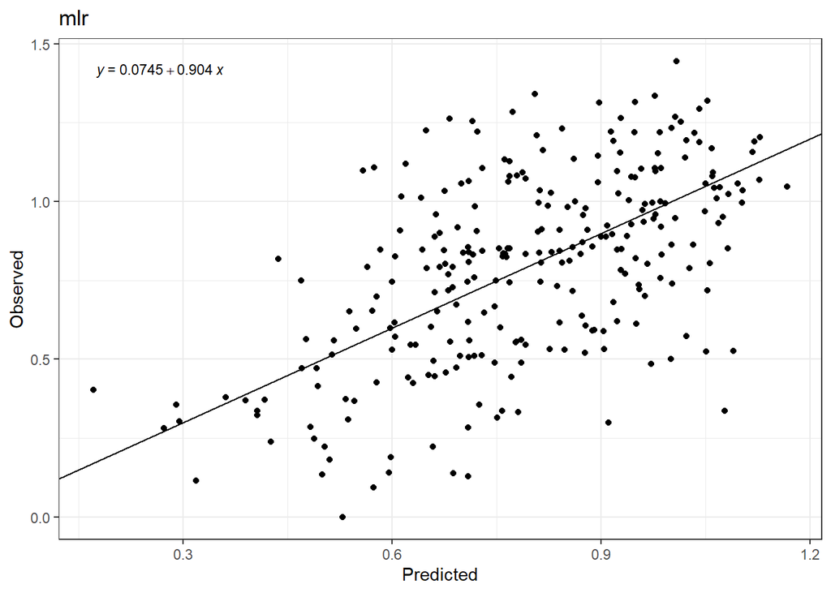

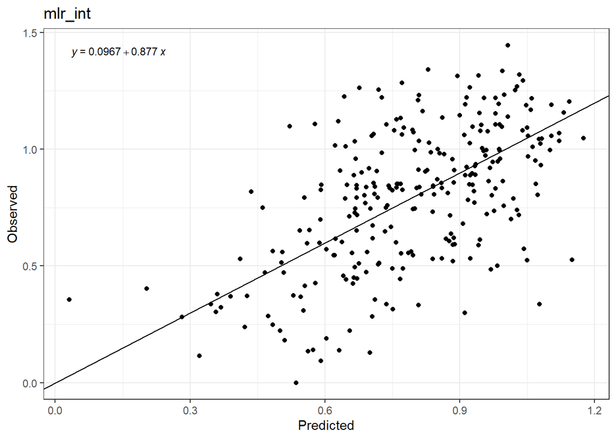

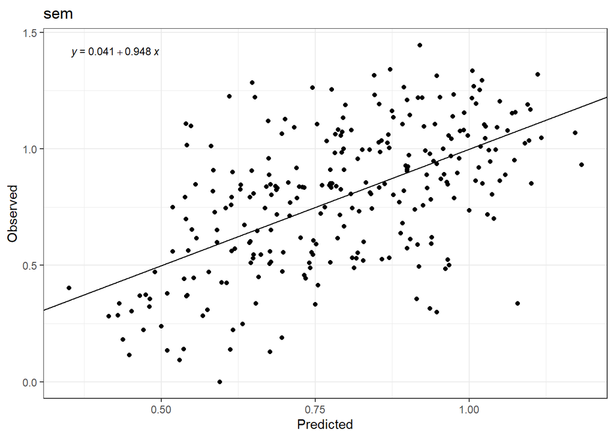

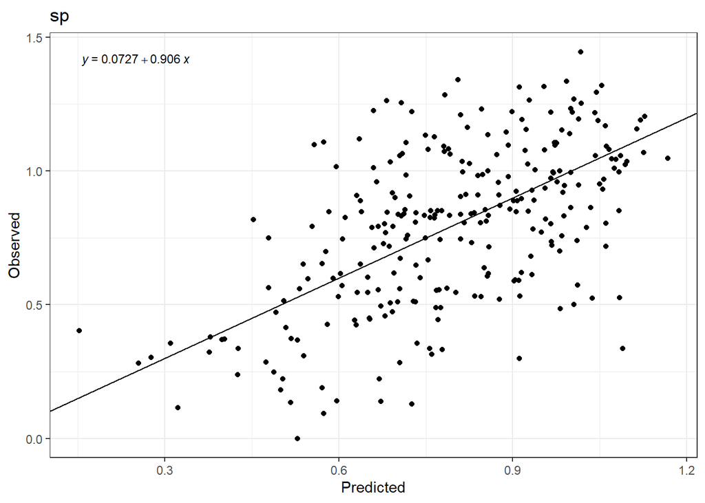

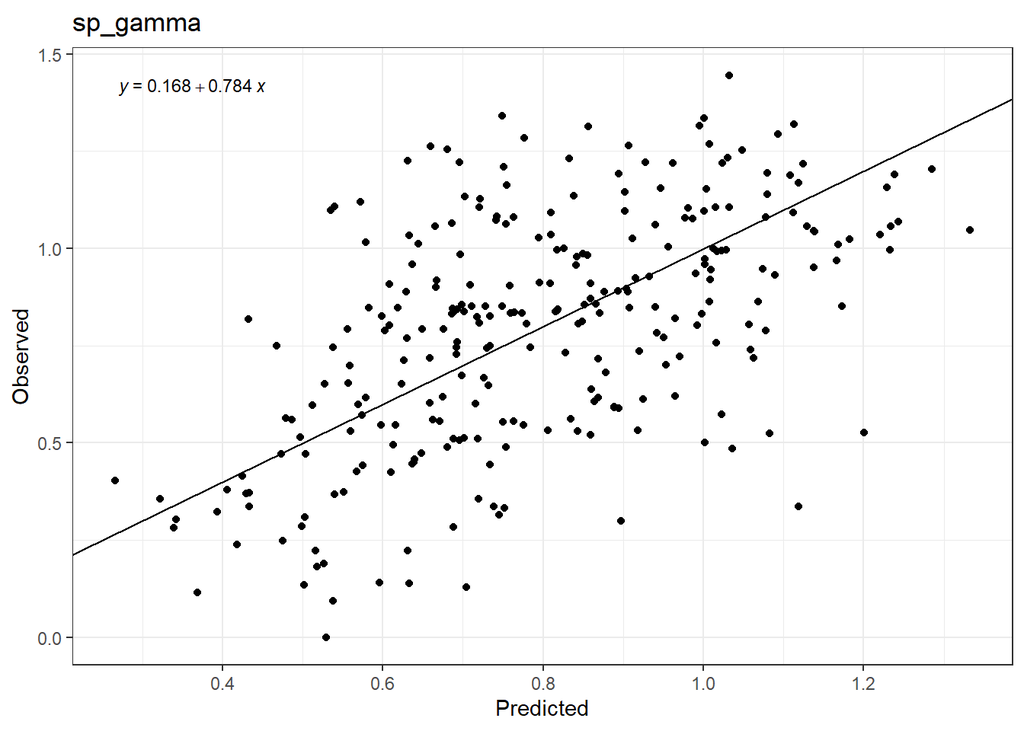

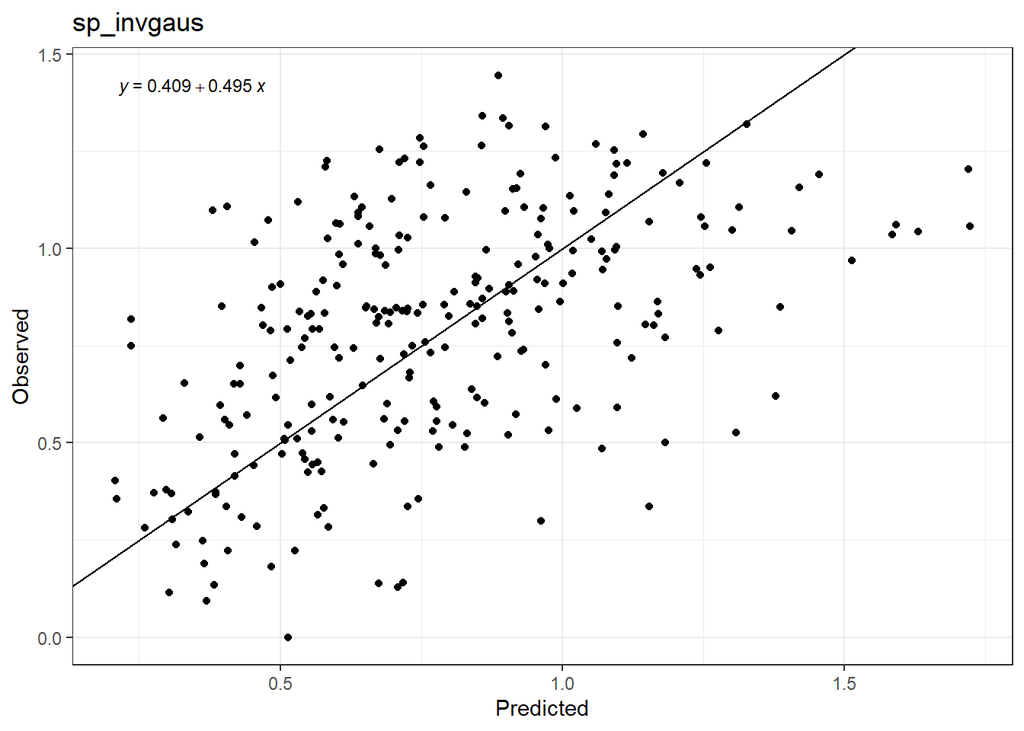

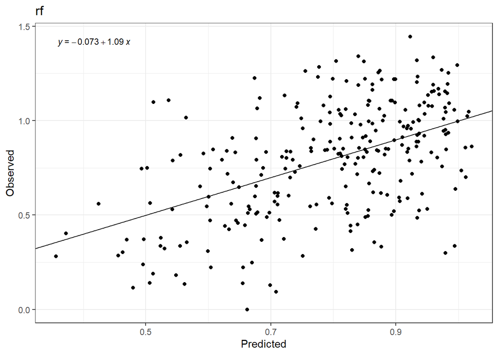

# Comparing Predicted vs Observed to Observed vs Predicted

Piniero et al. 2008 demonstrates that regressing observed vs predicted is the more appropriate method to evaluate slope and intercept. Slope close to 1 indicates consistency in observed and predicted values. Intercept close to 0 indicates less bias in observed and predicted.

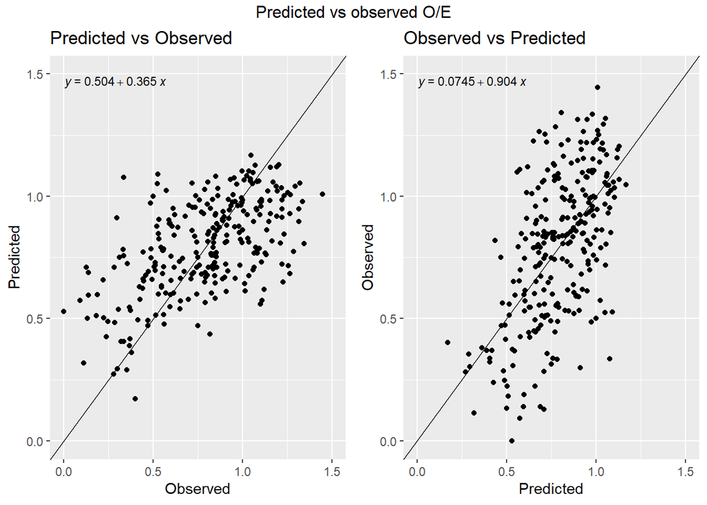

```
##
## Call:
## lm(formula = obs ~ mlr, data = predictions)
##
## Residuals:
##      Min       1Q   Median       3Q      Max
## -0.71314 -0.17992  0.00213  0.15572  0.57151
##
## Coefficients:
##             Estimate Std. Error t value Pr(>|t|)
## (Intercept)  0.07449    0.06411   1.162    0.246
## mlr          0.90442    0.07855  11.514   <2e-16 ***
## ---
## Signif. codes:  0 '***' 0.001 '**' 0.01 '*' 0.05 '.' 0.1 ' ' 1
##
## Residual standard error: 0.2466 on 269 degrees of freedom
## Multiple R-squared:  0.3302, Adjusted R-squared:  0.3277
## F-statistic: 132.6 on 1 and 269 DF,  p-value: < 2.2e-16
```

[output not shown]

[output not shown]